# Open Case Studies : Youth Disconnection

**This is how I will communicate general comments via this draft**

**MICHAEL ONTIVEROS**

*A quick search of my name will lead you to comments embedded in a green bubble like this.*

**This is how I will communicate problems via this draft**

**MICHAEL ONTIVEROS**

*Things in a red bubble like this must be addressed.*

**This is a real example of the above**

**MICHAEL ONTIVEROS**

*“css: style.css” is not included in the YAML metadata for this document.*

**This is a another real example of the above**

**MICHAEL ONTIVEROS**

*There are some existing typos in the tables in addition to those produced during the use of Magick. I made some assumptions along the way, documenting them. These need to be checked for accuracy.*

**Disclaimer**: The purpose of the [Open Case Studies](https://opencasestudies.github.io) project is **to demonstrate the use of various data science methods, tools, and software in the context of messy, real-world data**. A given case study does not cover all aspects of the research process, is not claiming to be the most appropriate way to analyze a given data set, and should not be used in the context of making policy decisions without external consultation from scientific experts.

## **Motivation**

https://onlinelibrary.wiley.com/doi/full/10.1111/1468-0009.12425

PDF of interest

Page 39

https://ssrc-static.s3.amazonaws.com/moa/Making%20the%20Connection.pdf

## **Main Questions**

**Our main question:**

1. What differences in youth disconnection rates exist in 2017?

## **Learning Objectives**

In this case study, we will demonstrate how to import and wrangle data available in the **P**ortable **D**ocument **F**ormat (**PDF**). We will especially focus on using packages and functions from the [`Tidyverse`](https://www.tidyverse.org/), such as `dplyr`, `ggplot2`. The tidyverse is a library of packages created by RStudio. While some students may be familiar with previous R programming packages, these packages make data science in R especially efficient.

[figure not shown]

We will begin by loading the packages that we will need:

```r
library(here)
library(tidyverse)
library(pdftools)
library(magick)
library(cowplot)
```

**MICHAEL ONTIVEROS** *I changed the way the table looks below to present the package names in bold. Many of these case studies have lots of text. Having important features of a case study presented in bold, italics, or both may make the document more easily interpretable. This is just my two ¢. Feel free to disregard this suggestion for any reason.*

| Package | Use |
| --- | --- |
| [**here**](https://github.com/jennybc/here_here) | to easily load and save data |
| [**tidyverse**](https://readr.tidyverse.org/) | for data science operations |
| [**pdftools**](https://readr.tidyverse.org/) | to manage PDF documents |
| [**magick**](https://cran.r-project.org/web/packages/magick/vignettes/intro.html#Kernel_convolution) | for image processing |

The first time we use a function, we will use the `::` to indicate which package we are using. Unless we have overlapping function names, this is not necessary, but we will include it here to be informative about where the functions we will use come from.

## **Limitations**

**MICHAEL ONTIVEROS**

*I compared the mechanics of image processing tools to a black box process. I feel it brings in some vocab while highlighting that this type of tool requires caution. Feel free to update as you think appropriate.*

There are some important considerations regarding this data analysis to keep in mind:

1. The statistical procedures we are using may be overly simplistic. *We need to be wary about deriving meaning from the statistical procedures we use*.
2. Using image processing tools can be very helpful. The manner in which data is obtained with image processing tools is what we would describe as a **black box process**, *a process with known inputs and outputs but unknown mechanics*. Because we are unaware of how our outputs are generate from our inputs, we need to be wary of the output. With the small output we are creating in this case study, a visual inspection should suffice.

## **What are the data?**

Discussion about data source/organization/organization mission or the like.

The data come from a PDF that can be found [**here**](https://ssrc-static.s3.amazonaws.com/moa/Making%20the%20Connection.pdf).

## **Data Import**

We import the data using the `pdftools` and `here` packages.

From the output, it’s clear that a large amount of manipulation will be required to wrangle this data with the `pdftools` package.

```r
pdf_data_example <- pdftools::pdf_data(here("Making the Connection.pdf"))

utils::head(pdf_data_example, 1)
```

```
[[1]]
# A tibble: 51 x 6
   width height     x     y space text
   <int>  <int> <int> <int> <lgl> <chr>
 1    74     23    36    53 TRUE  KRISTEN
 2    54     23   115    53 FALSE LEWIS
 3    31     11    36    79 TRUE  Rupsha
 4    20     11    69    79 TRUE  Basu
 5     2     11    94    79 TRUE  |
 6    34     11   101    79 TRUE  REPORT
 7    43     11   138    79 FALSE DESIGNER
 8    34     11    36    92 TRUE  Rebecca
 9    31     11    73    92 TRUE  Gluskin
10     2     11   109    92 TRUE  |
# … with 41 more rows
```

```r
pdf_tools_example <- pdftools::pdf_text(here("Making the Connection.pdf"))

head(pdf_tools_example, 1)
```

```
[1] "KRISTEN LEWIS\nRupsha Basu | REPORT DESIGNER\nRebecca Gluskin | CHIEF STATISTICIAN\nLaura Laderman | DATA ANALYST\nVikki Lassiter | STAKEHOLDER ENGAGEMENT\nBecky Ofrane | RESEARCHER\nBeth Post | REPORT DESIGNER\nMarina Recio | RESEARCHER\nMAKING THE CONNECTION\nTRANSPORTATION AND YOUTH DISCONNE…
```

While not impossible, it’s hard to argue that using the `pdftools` package in this scenario will require a lot of advanced data wrangling. While our output may be reproducible, the amount of time to achieve this reproducibility may not be any more efficient than typing the table by hand into a text or spreadsheet program.

Fortunately, there is another way we can proceed to wrangle the data.

We will demonstrate how to produce reproducible tables with image processing software on `R`.

For demonstrative purposes, we will import two sets of data. The first set of data will be used to highlight common errors that the image processing software may produce. The second set of data will be used to demonstrate how to circumvent these errors and, resultantly, produce reproducible datasets efficient.

We import the data using the `magick` and `here` packages.

```r
#bold is causing issues
image_example <- magick::image_read(here::here("gender_race_ethnicity.png"))

magick::image_info(image_example)
```

```
# A tibble: 1 x 7
  format width height colorspace matte filesize density
  <chr>  <int>  <int> <chr>      <lgl>    <int> <chr>
1 PNG      997    711 sRGB       TRUE    164964 72x72
```

We import the same data—this time without regions of the table without special formatting—using the `magick` and `here` packages.

```r
#bold is causing issues
image1 <- image_read(here("gender_race_ethnicity2.png"))

magick::image_info(image1)
```

```
# A tibble: 1 x 7
  format width height colorspace matte filesize density
  <chr>  <int>  <int> <chr>      <lgl>    <int> <chr>
1 PNG     1259    731 sRGB       TRUE    188256 72x72
```

## **Data Exploration and Wrangling**

The first image we imported looks like this.

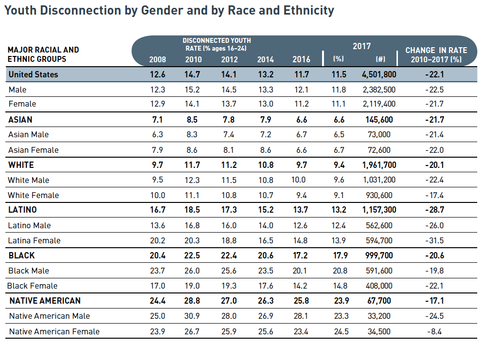

```r
image_example
```

Parts of the table depicted in the image above contain [**newline**](https://en.wikipedia.org/wiki/Newline?oldformat=true) characters. A newline character denotes the end of a line of text and the start of a new line of text.

This makes it more difficult to wrangle this table. Wrangling the data via regular expressions may be very tedious. It’s unlikely that image processing software can handle the newline characters—or any other special characters—correctly.

Using `image_ocr()` by `magick` on the image above will render some errors in the first few lines.

```r
df1 <- magick::image_ocr(image_example)

df1 %>%
  base::strsplit("\n") %>%
  base::unlist() %>%
  tibble::as_tibble()
```

```
# A tibble: 21 x 1
   value
   <chr>
 1 Youth Disconnection by Gender and by Race and Ethnicity
 2 byte) ee
 3 MAJOR RACIAL AND Cr erent) ed Nas
 4 United States 126 147 14.1 13.21.7115 4,501,800 22.1
 5 Male 12.3 15.2 14.5 13.3 12.1 11.8 2,382,500 -22.5
 6 Female 12.9 14.1 13.7 13.0 11.2 11.1 2,119,400 -21.7
 7 ASIAN 71 85 78 19 66 66 145,600 -21.7
 8 Asian Male 6.3 8.3 74 7.2 6.7 65 73,000 -21.4
 9 Asian Female 7.9 8.6 8.1 8.6 6.6 6.7 72,600 -22.0
10 WHITE 97 210897 9.4 1,961,700 -20.1
# … with 11 more rows
```

If we remove these lines, some new errors emerge.

```r
df1 %>%
    base::strsplit("\n") %>%
  base::unlist() %>%
  tibble::as_tibble() %>%
  dplyr::slice(-(1:3))
```

```
# A tibble: 18 x 1
   value
   <chr>
 1 United States 126 147 14.1 13.21.7115 4,501,800 22.1
 2 Male 12.3 15.2 14.5 13.3 12.1 11.8 2,382,500 -22.5
 3 Female 12.9 14.1 13.7 13.0 11.2 11.1 2,119,400 -21.7
 4 ASIAN 71 85 78 19 66 66 145,600 -21.7
 5 Asian Male 6.3 8.3 74 7.2 6.7 65 73,000 -21.4
 6 Asian Female 7.9 8.6 8.1 8.6 6.6 6.7 72,600 -22.0
 7 WHITE 97 210897 9.4 1,961,700 -20.1
 8 White Male 95 12.3 11.5 10.8 10.0 9.6 1,031,200 -22.4
 9 White Female 10.0 11.1 10.8 10.7 9.4 91 930,600 -17.4
10 LATINO 167-185 17.3 15.2 13.7 =~ 138.2_—_—‘1,157,300 -28.7
11 Latino Male 13.6 16.8 16.0 14.0 12.6 12.4 562,600 -26.0
12 Latina Female 20.2 20.3 18.8 16.5 14.8 13.9 594,700 -31.5
13 BLACK 20.4 225 224 206 17.2 17.9 999,700 -20.6
14 Black Male 23.7 26.0 25.6 23.5 20.1 20.8 591,600 -19.8
15 Black Female 17.0 19.0 19.3 17.6 14.2 14.8 408,000 -22.1
16 NATIVE AMERICAN 264 288 27.0 23 28 23.9 67,700 -17.1
17 Native American Male 25.0 30.9 28.0 26.9 28.1 23.3 33,200 -24.5
18 Native American Female 23.9 26.7 25.9 25.6 23.4 24.5 34,500 -B.4
```

Data wrangling is not an exact science. The approaches we can take are extremely dependent on the data. We can exploit patterns in the data to render the output we desire.

We will now use a cropped version of image above without the special formatting.

```r
rm(df1)

image_info(image1)
```

```
# A tibble: 1 x 7
  format width height colorspace matte filesize density
  <chr>  <int>  <int> <chr>      <lgl>    <int> <chr>
1 PNG     1259    731 sRGB       TRUE    188256 72x72
```

[output not shown]

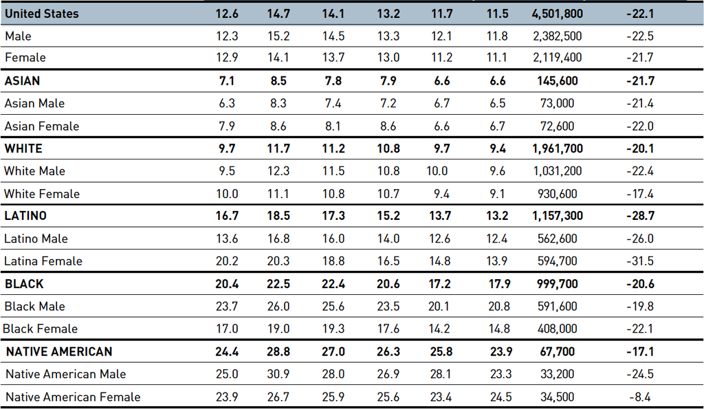

```r
base::print(image1)
```

```r
df1 <- image_ocr(image1)

df1 <- df1 %>%
  strsplit("\n") %>%
  unlist() %>%
  as_tibble()
```

We have several strings. Each cell of data is on a string separated by space.

We separate each string by space.

```r
df1 <- df1 %>%
  dplyr::select(value) %>%
  pull(value) %>%
  str_split(" ")
```

We split the dataframe in two: a labels section and a “data” section containing the information we are interested in.

In the first half, we remove all digits and punctuation to ensure that we are left with character labels.

In the second-half, remove commas and periods, converting the resulting string character class to numeric and selectively multiplying columns to reintroduce the decimal point correctly

```r
df1a <- df1 %>%
  purrr::map(~base::paste(.,collapse = "")) %>%
  purrr::map(~base::gsub("[[:digit:]]+|[[:punct:]]+", "",.)) %>%
  base::do.call(base::rbind,.) %>%
  base::data.frame() %>%
  dplyr::tibble()

df1b <- map(df1, tail, 8) %>%
  map(~gsub("[,]+|[.]+", "",.)) %>%
  do.call(rbind,.) %>%
  data.frame() %>%
  dplyr::mutate_if(base::is.character, base::as.numeric) %>%
  dplyr::mutate_at(vars(-X7), ~ . * 0.1) %>%
  tibble()

base::rm(df1)
```

We combine the two sections of data to create our dataframe, removing and then adding column names.

```r
df1 <- dplyr::bind_cols(df1a,
                        df1b)

base::names(df1) <- c()

column_names <- c("Group",
                  "Perc_2008",
                  "Perc_2010",
                  "Perc_2012",
                  "Perc_2014",
                  "Perc_2016",
                  "Perc_2017",
                  "N_2017",
                  "Delta_perc")

base::colnames(df1) <- column_names
```

We remove columns with information we don’t need and use the commmon pattern in the column names to convert the data into [long/narrow format](https://en.wikipedia.org/wiki/Wide_and_narrow_data?oldformat=true).

```r
df1 <- df1 %>%
  dplyr::select(-N_2017,
                -Delta_perc)

df1 <- df1 %>%
  tidyr::pivot_longer(cols=contains("Perc_"),
                      names_to = "Year",
                      values_to = "Rate",
                      names_prefix = "Perc_") %>%
  dplyr::mutate(Year = as.numeric(Year))
```

We use the `dplyr::case_when()` and `stringr::str_detect()` function to detect patterns and create an separate column with gender and race information.

The two columns created contain `TRUE/FALSE` statements. These are then used to create a third column that will allow us to separate the data by its summary level.

```r
df1 <- df1 %>%
  mutate(Gender = dplyr::case_when(stringr::str_detect(Group, "Female") ~ TRUE,
                            stringr::str_detect(Group, "Male") ~ FALSE,
                            TRUE ~ NA),
         Race = stringr::str_remove_all(Group,
                               pattern = paste(c("Female","Male","UnitedStates"),
                                               collapse = "|"))) %>%
  mutate(Race = dplyr::na_if(Race, ""))

df1 <- df1 %>%
  mutate(Type = case_when(base::is.na(Gender) & base::is.na(Race) ~ "US Total",
                          base::is.na(Gender) & !base::is.na(Race) ~ "Race Total",
                          !base::is.na(Gender) & base::is.na(Race) ~ "Gender Total",
                          TRUE ~ "Subgroup Total"))

df1 <- df1 %>%
  mutate(Gender = case_when(str_detect(Group, "Female") ~ "Female",
                            str_detect(Group, "Male") ~ "Male"))
```

The columns of `character` class currently contain upper and lower case characters. We want to ensure that we use a cases consistently to ensure that there are no errors driven by case-sensitive function downstream.

To do this, we use the `base::to_upper()` function. This function makes all characters uppercase.

```r
df1 <- df1 %>%
  mutate_if(is.character, toupper)
```

Finally, we homogenize the labels assigned for certain groups, fill in missing (`NA`) values with a string, and remove columns we no longer need from the dataframe.

```r
df1 <- df1 %>%
  mutate(Race = case_when(Race == "LATINA" ~ "LATINO/A",
                          Race == "LATINO" ~ "LATINO/A",
                          TRUE ~ Race)) %>%
  mutate(Gender = tidyr::replace_na(Gender, "ALL"),
         Race = tidyr::replace_na(Race, "ALL")) %>%
  dplyr::select(-Group)
```

We can repeat this process for the other two tables listed on page 39.

Let’s look at the table without the special formatting.

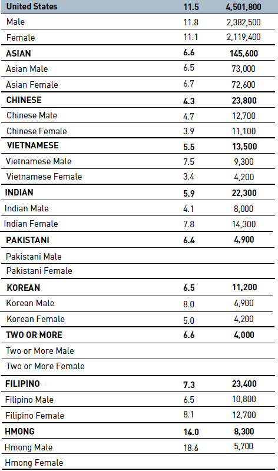

```r
image2 <- image_read(here("asian_subgroups.png"))
image2
```

As you can see, there are empty spaces. According to the PDF, these spaces are empty to denote that the estimates are unreliable.

This may cause problems. Whitespace must be handled differently. We may not want to process the entire image for this reason.

Instead, we can use separate images to ensure a simpler process like that above.

We read the three images.

```r
image2a <- image_read(here("asian_subgroupsA.png"))
image2b <- image_read(here("asian_subgroupsB.png"))
image2c <- image_read(here("asian_subgroupsC.png"))

magick::image_info(image2a)
```

```
# A tibble: 1 x 7
  format width height colorspace matte filesize density
  <chr>  <int>  <int> <chr>      <lgl>    <int> <chr>
1 PNG      757    687 sRGB       TRUE     95660 72x72
```

```r
magick::image_info(image2b)
```

```
# A tibble: 1 x 7
  format width height colorspace matte filesize density
  <chr>  <int>  <int> <chr>      <lgl>    <int> <chr>
1 PNG      751    177 sRGB       TRUE     28913 72x72
```

```r
magick::image_info(image2c)
```

```
# A tibble: 1 x 7
  format width height colorspace matte filesize density
  <chr>  <int>  <int> <chr>      <lgl>    <int> <chr>
1 PNG      760    216 sRGB       TRUE     33402 72x72
```

The images look like this.

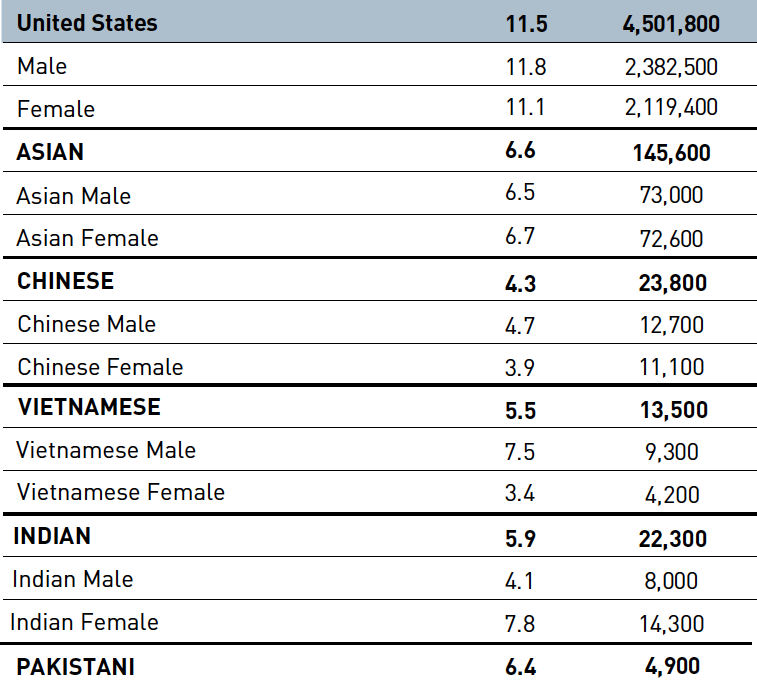

```r
image2a
```

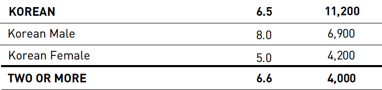

```r
image2b
```

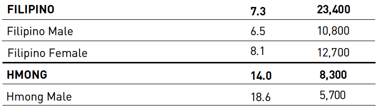

```r
image2c
```

We save the text from the images into objects.

```r
df2a <- magick::image_ocr(image2a)
df2b <- magick::image_ocr(image2b)
df2c <- magick::image_ocr(image2c)
```

We process these objects separately. Note that we use a very similar process to that employed in the wrangling of the previous table.

```r
df2a <- df2a %>%
  strsplit("\n") %>%
  unlist() %>%
  as_tibble()

df2b <- df2b %>%
  strsplit("\n") %>%
  unlist() %>%
  as_tibble()

df2c <- df2c %>%
  strsplit("\n") %>%
  unlist() %>%
  as_tibble()
```

We then combine the objects with the `dplyr::bind_rows()` function.

The process is now very similar to the previous table.

**MICHAEL ONTIVEROS**

*I used base R to remove the first three rows of a dataframe in the following chunk. I am not aware of a tidyverse solution for this; I am sure one exists.*

```r
df2 <- bind_rows(df2a,
          df2b,
          df2c)

df2 <- df2 %>%
  dplyr::select(value) %>%
  pull(value) %>%
  str_split(" ")

df2b <- map(df2, tail, 2) %>%
  map(~gsub("[,]+|[.]+", "",.)) %>%
  do.call(rbind,.) %>%
  data.frame() %>%
  mutate_if(is.character, as.numeric) %>%
  mutate_at(vars(-X2), ~ . * 0.1) %>%
  tibble()

df2a <- df2 %>%
  map(~paste(.,collapse = "")) %>%
  map(~gsub("[[:digit:]]+|[[:punct:]]+", "",.)) %>%
  do.call(rbind,.) %>%
  data.frame() %>%
  tibble()

df2 <- bind_cols(df2a, df2b)

names(df2) <- c()

column_names <- c("Group",
                  "Rate",
                  "N_2017")

colnames(df2) <- column_names

df2 <- df2 %>%
  dplyr::select(-N_2017)

df2 <- df2 %>%
  dplyr::mutate(Year = 2017)

df2 <- df2 %>%
  mutate(Gender = case_when(str_detect(Group, "Female") ~ TRUE,
                            str_detect(Group, "Male") ~ FALSE,
                            TRUE ~ NA),
         Subgroup = str_remove_all(Group,
                                   pattern = paste(c("Female",
                                                     "Male",
                                                     "ASIAN",
                                                     "Asian"),
                                               collapse = "|"))) %>%
  mutate(Subgroup = na_if(Subgroup, ""))

glimpse(df2)
```

```
Rows: 25
Columns: 5
$ Group    <chr> "UnitedStates", "Male", "Female", "ASIAN", "AsianMale", "Asi…
$ Rate     <dbl> 11.5, 11.8, 11.1, 6.6, 6.5, 6.7, 4.3, 4.7, 3.9, 5.5, 7.5, 3.…
$ Year     <dbl> 2017, 2017, 2017, 2017, 2017, 2017, 2017, 2017, 2017, 2017, …
$ Gender   <lgl> NA, FALSE, TRUE, NA, FALSE, TRUE, NA, FALSE, TRUE, NA, FALSE…
$ Subgroup <chr> "UnitedStates", NA, NA, NA, NA, NA, "CHINESE", "Chinese", "C…
```

```r
df2 <- df2[-(1:3),]

df2 <- df2 %>%
  mutate(Type = case_when(is.na(Gender) & is.na(Subgroup) ~ "Asian Total",
                          is.na(Gender) & !is.na(Subgroup) ~ "Subgroup Total",
                          !is.na(Gender) & is.na(Subgroup) ~ "Gender Total",
                          TRUE ~ "Subgroup Total"))

glimpse(df2)
```

```
Rows: 22
Columns: 6
$ Group    <chr> "ASIAN", "AsianMale", "AsianFemale", "CHINESE", "ChineseMale…
$ Rate     <dbl> 6.6, 6.5, 6.7, 4.3, 4.7, 3.9, 5.5, 7.5, 3.4, 5.9, 4.1, 7.8, …
$ Year     <dbl> 2017, 2017, 2017, 2017, 2017, 2017, 2017, 2017, 2017, 2017, …
$ Gender   <lgl> NA, FALSE, TRUE, NA, FALSE, TRUE, NA, FALSE, TRUE, NA, FALSE…
$ Subgroup <chr> NA, NA, NA, "CHINESE", "Chinese", "Chinese", "VIETNAMESE", "…
$ Type     <chr> "Asian Total", "Gender Total", "Gender Total", "Subgroup Tot…
```

```r
df2 <- df2 %>%
  mutate(Gender = case_when(str_detect(Group, "Female") ~ "Female",
                            str_detect(Group, "Male") ~ "Male"))

df2 <- df2 %>%
  mutate_if(is.character, tolower) %>%
  mutate_if(is.character, toupper)

df2 <- df2 %>%
  mutate(Gender = replace_na(Gender, "ALL"),
         Subgroup = replace_na(Subgroup, "ALL")) %>%
  dplyr::select(-Group) %>%
  mutate(Subgroup)

df2 <- df2 %>%
  mutate(Subgroup = case_when(Subgroup == "TWOORMORE" ~ "TWO OR MORE",
                              TRUE ~ Subgroup))
```

Note that we took a process that had successfully worked for us and modified it slightly for separate, similarly-sourced data.

This is a common approach in data science. Often, the duration of the wrangling process can limit the depth of an analysis for practical reasons. Using tried methods can help reduce the time needed to wrangle data and allow time for other parts of an analysis.

Let’s add the 2018 data for this group.

We import the image.

```r
image5 <- image_read(here("asian_subgroups_2018.png"))

df2_2018 <- magick::image_ocr(image5)
```

As you can see, we have repeated newlines (`\n`). We can remove these with some simplex regex.

```r
df2_2018 <- gsub('([\n])\\1+',
                 '\\1',
                 df2_2018)

df2_2018 <- gsub("[[:punct:]]+",
                 "",
                 df2_2018)

df2_2018 <- gsub(" i ",
                 "",
                 df2_2018)
```

We proceed, making slight modifications to the process as needed.

The bold font appears to have caused a typos.

```r
df2_2018 %>%
  strsplit("\n") %>%
  unlist() %>%
  as_tibble()
```

```
# A tibble: 17 x 1
   value
   <chr>
 1 CHINESE  41  23300
 2 Men  45  12500
 3 Women  37 10800
 4 INDIAN  B44  21800
 5 Men  47  10400
 6 Women  61  11300
 7 KOREAN  55  9000
 8 Men  56  4700
 9 Women  54  4300
10 VIETNAMESE  63  15300
11 Men  76  9000
12 Women  50  6400
13 FILIPINO  68  20800
14 Men  63  10000
15 Women74  10800
16 HMONG102  5300
17 CAMBODIAN 138  4200
```

We fix the typos.

```r
df2_2018 <- df2_2018 %>%
  strsplit("\n") %>%
  unlist() %>%
  gsub(" B44 ","54",.) %>%
  gsub("Women74","Women 74",.) %>%
  gsub("HMONG102","HMONG 102",.) %>%
  as_tibble()

df2_2018 %>%
  print(.,n = dim(.)[1])
```

```
# A tibble: 17 x 1
   value
   <chr>
 1 CHINESE  41  23300
 2 Men  45  12500
 3 Women  37 10800
 4 INDIAN 54 21800
 5 Men  47  10400
 6 Women  61  11300
 7 KOREAN  55  9000
 8 Men  56  4700
 9 Women  54  4300
10 VIETNAMESE  63  15300
11 Men  76  9000
12 Women  50  6400
13 FILIPINO  68  20800
14 Men  63  10000
15 Women 74  10800
16 HMONG 102  5300
17 CAMBODIAN 138  4200
```

We then continue as we would normally.

```r
df2_2018 <- df2_2018 %>%
  dplyr::select(value) %>%
  pull(value) %>%
  str_split(" ")

df2_2018 <- lapply(df2_2018,
                   function(x) x[nchar(x) >= 1])

df2a_2018 <- df2_2018 %>%
  map(~paste(.,collapse = "")) %>%
  map(~gsub("[[:digit:]]+|[[:punct:]]+", "",.)) %>%
  do.call(rbind,.) %>%
  data.frame() %>%
  tibble()

df2b_2018 <- map(df2_2018, tail, 2) %>%
  do.call(rbind,.) %>%
  data.frame() %>%
  mutate_if(is.character, as.numeric) %>%
  mutate_at(vars(-X2), ~ . * 0.1) %>%
  tibble()

rm(df2_2018)

df2_2018 <- bind_cols(df2a_2018,
                      df2b_2018)
names(df2_2018) <- c()

column_names <- c("Group",
                  "Rate",
                  "N_2017")

colnames(df2_2018) <- column_names

df2_2018 <- df2_2018 %>%
  dplyr::select(-N_2017)

df2_2018 <- df2_2018 %>%
  dplyr::mutate(Year = 2018)

df2_2018 <- df2_2018 %>%
  mutate(Gender = case_when(str_detect(Group, "Women") ~ TRUE,
                            str_detect(Group, "Men") ~ FALSE,
                            TRUE ~ NA))

labels <- unlist(df2_2018[c(seq(1,15, by=3),16,17),1], use.names = FALSE)

dim(df2_2018)[1]
```

```
[1] 17
```

```r
labels_3 <- c(rep(labels[1:5], each = dim(df2_2018)[1]/(length(labels)-2)),
              "HMONG",
              "CAMBODIAN")

df2_2018$Subgroup <- labels_3

df2_2018 <- df2_2018 %>%
  mutate(Type = "Subgroup Total")

glimpse(df2_2018)
```

```
Rows: 17
Columns: 6
$ Group    <chr> "CHINESE", "Men", "Women", "INDIAN", "Men", "Women", "KOREAN…
$ Rate     <dbl> 4.1, 4.5, 3.7, 5.4, 4.7, 6.1, 5.5, 5.6, 5.4, 6.3, 7.6, 5.0, …
$ Year     <dbl> 2018, 2018, 2018, 2018, 2018, 2018, 2018, 2018, 2018, 2018, …
$ Gender   <lgl> NA, FALSE, TRUE, NA, FALSE, TRUE, NA, FALSE, TRUE, NA, FALSE…
$ Subgroup <chr> "CHINESE", "CHINESE", "CHINESE", "INDIAN", "INDIAN", "INDIAN…
$ Type     <chr> "Subgroup Total", "Subgroup Total", "Subgroup Total", "Subgr…
```

```r
df2_2018 <- df2_2018 %>%
  mutate(Gender = case_when(Gender == TRUE ~ "Female",
                            Gender == FALSE ~ "Male",
                            TRUE ~ "All"))

df2_2018 <- df2_2018 %>%
  mutate_if(is.character, tolower) %>%
  mutate_if(is.character, toupper)

df2_2018 <- df2_2018 %>%
  dplyr::select(-Group)
```

The dataframe we produced does not contain totals.

```r
df2_2018 %>%
  print(., n = dim(.)[1])
```

```
# A tibble: 17 x 5
    Rate  Year Gender Subgroup   Type
   <dbl> <dbl> <chr>  <chr>      <chr>
 1   4.1  2018 ALL    CHINESE    SUBGROUP TOTAL
 2   4.5  2018 MALE   CHINESE    SUBGROUP TOTAL
 3   3.7  2018 FEMALE CHINESE    SUBGROUP TOTAL
 4   5.4  2018 ALL    INDIAN     SUBGROUP TOTAL
 5   4.7  2018 MALE   INDIAN     SUBGROUP TOTAL
 6   6.1  2018 FEMALE INDIAN     SUBGROUP TOTAL
 7   5.5  2018 ALL    KOREAN     SUBGROUP TOTAL
 8   5.6  2018 MALE   KOREAN     SUBGROUP TOTAL
 9   5.4  2018 FEMALE KOREAN     SUBGROUP TOTAL
10   6.3  2018 ALL    VIETNAMESE SUBGROUP TOTAL
11   7.6  2018 MALE   VIETNAMESE SUBGROUP TOTAL
12   5    2018 FEMALE VIETNAMESE SUBGROUP TOTAL
13   6.8  2018 ALL    FILIPINO   SUBGROUP TOTAL
14   6.3  2018 MALE   FILIPINO   SUBGROUP TOTAL
15   7.4  2018 FEMALE FILIPINO   SUBGROUP TOTAL
16  10.2  2018 ALL    HMONG      SUBGROUP TOTAL
17  13.8  2018 ALL    CAMBODIAN  SUBGROUP TOTAL
```

We can find these totals in the PDF directly and create rows as needed

We load the PDF.

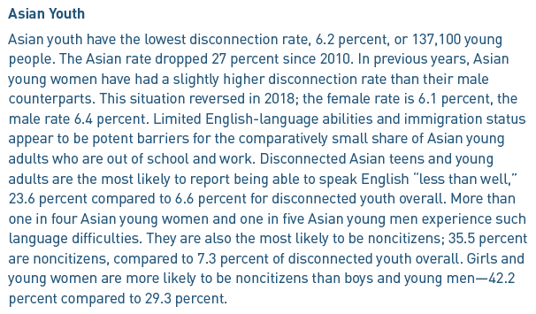

```r
excerpt <- image_read(here("asian_youth_excerpt.png"))

excerpt
```

We add the rows.

```r
df2_2018 <- df2_2018 %>%
  add_row(Rate = 6.2,
          Year = 2018,
          Gender = "ALL",
          Subgroup = "ALL",
          Type = "ASIAN TOTAL") %>%
  add_row(Rate = 6.1,
          Year = 2018,
          Gender = "FEMALE",
          Subgroup = "ALL",
          Type = "GENDER TOTAL") %>%
  add_row(Rate = 6.4,
          Year = 2018,
          Gender = "MALE",
          Subgroup = "ALL",
          Type = "GENDER TOTAL")
```

```r
df2 <- bind_rows(df2,
                 df2_2018)
```

We repeat this process again for Latino/a subgroups.

```r
image3 <- image_read(here("latino_a_subgroups.png"))
```

There are no whitespaces in this table.

We proceed using what we’ve learned while wrangling the first two tables.

```r
df3 <- magick::image_ocr(image3)

df3 %>%
  base::strsplit("\n") %>%
  base::unlist() %>%
  tibble::as_tibble()
```

```
# A tibble: 17 x 1
   value
   <chr>
 1 LATINO 13.2 1,157,300
 2 Latino Male 12.4 562,600
 3 Latina Female 13.9 594,700
 4 SOUTH AMERICAN 8.4 37,600
 5 South American Male 9.1 20,400
 6 South American Female 17 17,200
 7 CENTRAL AMERICAN 12.0 93,100
 8 Central American Male 9.3 37,900
 9 Central American Female 15.0 55,200
10 MEXICAN 13.3 762,400
11 Mexican Male 12.2 358,200
12 Mexican Female 14.4 404,200
13 OTHER LATINO 13.6 44,800
14 Other Latino Male 15.3 27,600
15 Other Latina Female 11.5 17,300
16 PR, DR, Cuban Female 15.7 114,500
17 PR, DR, Cuban Female 14.4 96,600
```

We are often presented with scenarios where stand-alone approaches are difficult or time-consuming.

It is always best to document the steps take to respond to these scenarios. Wrangling this third table is a prime example of this.

We are missing a row. Let’s manually add the row.

```r
df3 <- df3 %>%
  strsplit("\n") %>%
  unlist() %>%
  as_tibble()

df3 <- df3 %>%
  rbind("PR, DR, Cuban 15.1 211,200")
```

We can now proceed as we did with the previous tables.

```r
df3 <- df3 %>%
  dplyr::select(value) %>%
  pull(value) %>%
  str_split(" ")

df3b <- map(df3, tail, 2) %>%
  map(~gsub("[,]+|[.]+", "",.)) %>%
  do.call(rbind,.) %>%
  data.frame() %>%
  mutate_if(is.character, as.numeric) %>%
  mutate_at(vars(-X2), ~ . * 0.1) %>%
  tibble()

df3a <- df3 %>%
  map(~paste(.,collapse = "")) %>%
  map(~gsub("[[:digit:]]+|[[:punct:]]+", "",.)) %>%
  do.call(rbind,.) %>%
  data.frame() %>%
  tibble()

rm(df3)

df3 <- bind_cols(df3a, df3b)
names(df3) <- c()

column_names <- c("Group",
                  "Rate",
                  "N_2017")

colnames(df3) <- column_names
```

If we look at the last few rows, we see that there is a typo. There are two female groups.

```r
tail(df3)
```

```
# A tibble: 6 x 3
  Group              Rate N_2017
  <chr>             <dbl>  <dbl>
1 OTHERLATINO        13.6  44800
2 OtherLatinoMale    15.3  27600
3 OtherLatinaFemale  11.5  17300
4 PRDRCubanFemale    15.7 114500
5 PRDRCubanFemale    14.4  96600
6 PRDRCuban          15.1 211200
```

Sometimes when wrangling text data, we will come across a typo. We need to determine how to respond to the typo and make note of it. It’s often best to consult a secondary source to confirm that changes made are accurate.

For the purposes of this case study, we will assume that the first of the two rows represents male disconnection rates in the Latino/a subgroup; this would be consistent with the ordering of genders in the previous subgroups.

Let’s make the correction to the typo.

```r
df3 <- df3 %>%
  mutate(Group = case_when(Group == "PRDRCubanFemale" & N_2017 == 114500 ~ "PRDRCubanMale",
                         TRUE ~ Group))
```

It looks like we’ve succesfully corrected the typo.

```r
tail(df3)
```

```
# A tibble: 6 x 3
  Group              Rate N_2017
  <chr>             <dbl>  <dbl>
1 OTHERLATINO        13.6  44800
2 OtherLatinoMale    15.3  27600
3 OtherLatinaFemale  11.5  17300
4 PRDRCubanMale      15.7 114500
5 PRDRCubanFemale    14.4  96600
6 PRDRCuban          15.1 211200
```

We can continue with the process we’ve developed now that we have made the correction.

```r
df3 <- df3 %>%
  dplyr::select(-N_2017)

df3 <- df3 %>%
  dplyr::mutate(Year = 2017)

df3 <- df3 %>%
  mutate(Gender = case_when(str_detect(Group, "Female") ~ TRUE,
                            str_detect(Group, "Male") ~ FALSE,
                            TRUE ~ NA),
         Subgroup = str_remove_all(Group,
                                   pattern = paste(c("Female",
                                                     "Male",
                                                     "LATINO",
                                                     "Latino",
                                                     "Latina"),
                                               collapse = "|"))) %>%
  mutate(Subgroup = na_if(Subgroup, ""))

glimpse(df3)
```

```
Rows: 18
Columns: 5
$ Group    <chr> "LATINO", "LatinoMale", "LatinaFemale", "SOUTHAMERICAN", "So…
$ Rate     <dbl> 13.2, 12.4, 13.9, 8.4, 9.1, 1.7, 12.0, 9.3, 15.0, 13.3, 12.2…
$ Year     <dbl> 2017, 2017, 2017, 2017, 2017, 2017, 2017, 2017, 2017, 2017, …
$ Gender   <lgl> NA, FALSE, TRUE, NA, FALSE, TRUE, NA, FALSE, TRUE, NA, FALSE…
$ Subgroup <chr> NA, NA, NA, "SOUTHAMERICAN", "SouthAmerican", "SouthAmerican…
```

```r
df3 <- df3 %>%
  mutate(Type = case_when(is.na(Gender) & is.na(Subgroup) ~ "Latino/a Total",
                          is.na(Gender) & !is.na(Subgroup) ~ "Subgroup Total",
                          !is.na(Gender) & is.na(Subgroup) ~ "Gender Total",
                          TRUE ~ "Subgroup Total"))

glimpse(df3)
```

```
Rows: 18
Columns: 6
$ Group    <chr> "LATINO", "LatinoMale", "LatinaFemale", "SOUTHAMERICAN", "So…
$ Rate     <dbl> 13.2, 12.4, 13.9, 8.4, 9.1, 1.7, 12.0, 9.3, 15.0, 13.3, 12.2…
$ Year     <dbl> 2017, 2017, 2017, 2017, 2017, 2017, 2017, 2017, 2017, 2017, …
$ Gender   <lgl> NA, FALSE, TRUE, NA, FALSE, TRUE, NA, FALSE, TRUE, NA, FALSE…
$ Subgroup <chr> NA, NA, NA, "SOUTHAMERICAN", "SouthAmerican", "SouthAmerican…
$ Type     <chr> "Latino/a Total", "Gender Total", "Gender Total", "Subgroup …
```

```r
df3 <- df3 %>%
  mutate(Gender = case_when(str_detect(Group, "Female") ~ "Female",
                            str_detect(Group, "Male") ~ "Male"))

df3 <- df3 %>%
  mutate_if(is.character, tolower) %>%
  mutate_if(is.character, toupper)

df3 <- df3 %>%
  mutate(Gender = replace_na(Gender, "ALL"),
         Subgroup = replace_na(Subgroup, "ALL")) %>%
  dplyr::select(-Group) %>%
  mutate(Subgroup)

df3 <- df3 %>%
  mutate(Subgroup = case_when(Subgroup == "SOUTHAMERICAN" ~ "SOUTH AMERICAN",
                              Subgroup == "CENTRALAMERICAN" ~ "CENTRAL AMERICAN",
                              Subgroup == "PRDRCUBAN" ~ "PR/DR/CUBAN",
                              TRUE ~ Subgroup))
```

Let’s add the 2018 data to this dataframe.

We import the image.

```r
image5 <- image_read(here("latino_a_subgroups_2018.png"))

df3_2018 <- magick::image_ocr(image5)
```

As you can see, we have repeated newlines (`\n`). We can remove these with some simplex regex.

```r
df3_2018 <- gsub('([\n])\\1+',
                 '\\2',
                 df3_2018)

df3_2018 <- gsub("[[:punct:]]+",
                 "",
                 df3_2018)
```

We proceed, making slight modifications to the process as needed.

```r
df3_2018 <- df3_2018 %>%
  strsplit("\n") %>%
  unlist() %>%
  as_tibble()

df3_2018 <- df3_2018 %>%
  dplyr::select(value) %>%
  pull(value) %>%
  str_split(" ")

df3_2018 <- lapply(df3_2018,
                   function(x) x[nchar(x) >= 1])

df3a_2018 <- df3_2018 %>%
  map(~paste(.,collapse = "")) %>%
  map(~gsub("[[:digit:]]+|[[:punct:]]+", "",.)) %>%
  do.call(rbind,.) %>%
  data.frame() %>%
  tibble()

df3b_2018 <- map(df3_2018, tail, 2) %>%
  do.call(rbind,.) %>%
  data.frame() %>%
  mutate_if(is.character, as.numeric) %>%
  mutate_at(vars(-X2), ~ . * 0.1) %>%
  tibble()

rm(df3_2018)

df3_2018 <- bind_cols(df3a_2018,
                      df3b_2018)
names(df3_2018) <- c()

column_names <- c("Group",
                  "Rate",
                  "N_2017")

colnames(df3_2018) <- column_names

df3_2018 <- df3_2018 %>%
  dplyr::select(-N_2017)

df3_2018 <- df3_2018 %>%
  dplyr::mutate(Year = 2018)

df3_2018 <- df3_2018 %>%
  mutate(Gender = case_when(str_detect(Group, "Women") ~ TRUE,
                            str_detect(Group, "Men") ~ FALSE,
                            TRUE ~ NA))

labels <- unlist(df3_2018[seq(1,12, by =3),1], use.names = FALSE)

dim(df3_2018)[1]
```

```
[1] 12
```

```r
labels_3 <- rep(labels, each = dim(df3_2018)[1]/length(labels))

df3_2018$Subgroup <- labels_3

df3_2018 <- df3_2018 %>%
  mutate(Type = "Subgroup Total")

glimpse(df3_2018)
```

```
Rows: 12
Columns: 6
$ Group    <chr> "SOUTHAMERICAN", "Men", "Women", "MEXICAN", "Men", "Women", …
$ Rate     <dbl> 8.0, 7.5, 8.6, 12.9, 12.0, 13.8, 13.7, 14.9, 12.4, 13.7, 11.…
$ Year     <dbl> 2018, 2018, 2018, 2018, 2018, 2018, 2018, 2018, 2018, 2018, …
$ Gender   <lgl> NA, FALSE, TRUE, NA, FALSE, TRUE, NA, FALSE, TRUE, NA, FALSE…
$ Subgroup <chr> "SOUTHAMERICAN", "SOUTHAMERICAN", "SOUTHAMERICAN", "MEXICAN"…
$ Type     <chr> "Subgroup Total", "Subgroup Total", "Subgroup Total", "Subgr…
```

```r
df3_2018 <- df3_2018 %>%
  mutate(Gender = case_when(Gender == TRUE ~ "Female",
                            Gender == FALSE ~ "Male",
                            TRUE ~ "All"))

df3_2018 <- df3_2018 %>%
  mutate_if(is.character, tolower) %>%
  mutate_if(is.character, toupper)

df3_2018 <- df3_2018 %>%
  dplyr::select(-Group)

df3_2018 <- df3_2018 %>%
  mutate(Subgroup = case_when(Subgroup == "SOUTHAMERICAN" ~ "SOUTH AMERICAN",
                              Subgroup == "CENTRALAMERICAN" ~ "CENTRAL AMERICAN",
                              Subgroup == "PRDRCUBAN" ~ "PR/DR/CUBAN",
                              TRUE ~ Subgroup))
```

We load the PDF.

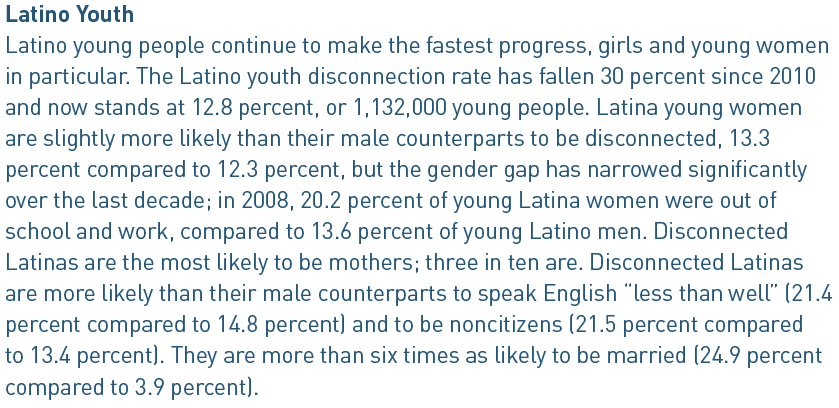

```r
rm(excerpt)
excerpt <- image_read(here("latino_a_youth_excerpt.png"))

excerpt
```

We add the rows.

```r
df3_2018 <- df3_2018 %>%
  add_row(Rate = 12.8,
          Year = 2018,
          Gender = "ALL",
          Subgroup = "ALL",
          Type = "LATINO/A TOTAL") %>%
  add_row(Rate = 13.3,
          Year = 2018,
          Gender = "FEMALE",
          Subgroup = "ALL",
          Type = "GENDER TOTAL") %>%
  add_row(Rate = 12.3,
          Year = 2018,
          Gender = "MALE",
          Subgroup = "ALL",
          Type = "GENDER TOTAL")
```

We add the 2018 data to the dataframe

```r
df3 <- bind_rows(df3,
                 df3_2018)
```

### Map

We will use multiple images to import the data on page 36 to produce maps.

**MICHAEL ONTIVEROS**

*This code is not complete. If there is time, we will return to it! Magick is having trouble with quadrant 1 and 4. I could not figure out why.*

```r
quadrant1 <- image_read(here("state_quadrant1.png"))
quadrant2 <- image_read(here("state_quadrant2.png"))
quadrant3 <- image_read(here("state_quadrant3.png"))
quadrant4 <- image_read(here("state_quadrant4.png"))

quadrant1 <- magick::image_ocr(quadrant1)
quadrant2 <- magick::image_ocr(quadrant2)
quadrant3 <- magick::image_ocr(quadrant3)
quadrant4 <- magick::image_ocr(quadrant4)

labels_quad1_3 <- paste0(quadrant1, quadrant3)
labels_quad2_4 <- paste0(quadrant2, quadrant4)

labels_quad1_3 <- labels_quad1_3 %>%
  strsplit("\n") %>%
  unlist() %>%
  as_tibble()

labels_quad2_4 <- labels_quad2_4 %>%
  strsplit("\n") %>%
  unlist() %>%
  as_tibble()

df1 <- df1 %>%
  dplyr::select(value) %>%
  pull(value) %>%
  str_split(" ")
```

```r
data_map <- map_data("state") %>%
  filter(region=="california")

years <- c(seq(2008,2016,by=2),2017)

index_rep <- dim(data_map)[1]

data_map <- bind_rows(replicate(length(years), data_map, simplify = FALSE))

data_map$year <- rep(years, each = index_rep)

data_map <- data_map %>%
  group_by(region, year) %>%
  mutate(rank_ran = rank(year, ties.method = "random"))

data_map <- data_map[order(data_map$order),]

library(gganimate)

ggplot(data_map, aes(x = long, y = lat, group = group, fill=rank_ran)) +
  geom_polygon() +
  transition_time(time = year)
```

## **Data Analysis**

**MICHAEL ONTIVEROS**

*We could introduce baseline adjustment to introduce a statistical concept. This would circumvent the need for a model that would capture the temporal autocorrelation present in panel data.*

## **Data Visualization**

Let’s reproduce the example below.

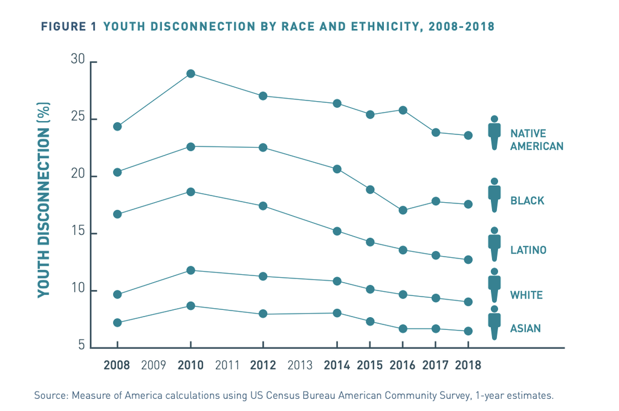

We can create a version of the above example with `ggplot` from `tidyverse`.

There are color identifying websites only such as [this](https://imagecolorpicker.com/en/).

Using one of these websites, we identify the [hex triplet](https://en.wikipedia.org/wiki/Web_colors?oldformat=true) for the color used in the visualization included in the PDF: `#008393`.

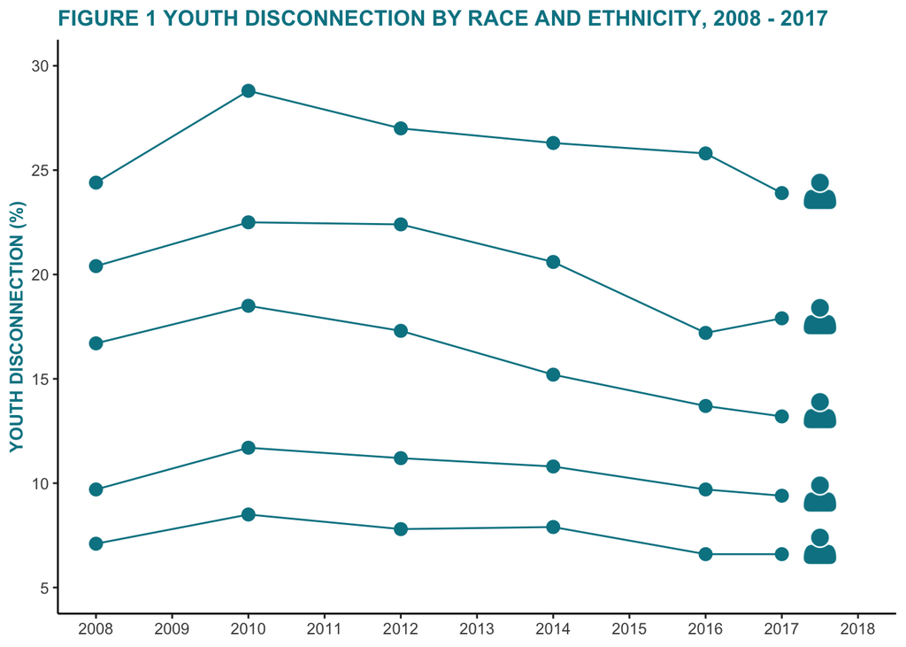

```r
fa_figurine <- image_read("https://upload.wikimedia.org/wikipedia/commons/7/7c/User_font_awesome.svg")

fa_figurine <- image_fill(fa_figurine,
                          color = "#008393",
                          point = "+800+800",
                          fuzz = 0)

fa_figurine <- image_fill(fa_figurine,
                          color = "#008393",
                          point = "+800+1000",
                          fuzz = 0)

df1 %>%
  filter(Type == "RACE TOTAL") %>%
  ggplot(aes(x = Year, y = Rate, group=Race)) +
  geom_line(color = "#008393", size = 0.5) +
  geom_point(color = "#008393", size = 3) +
  scale_x_continuous(breaks = seq(2008,2018, by=1),
                     limits = c(2008,2018)) +
  scale_y_continuous(breaks = seq(5,30, by =5),
                     limits = c(5,30)) +
  draw_image(fa_figurine, x = 2017, y = 23.5, scale = 2) +
  draw_image(fa_figurine, x = 2017, y = 17.5, scale = 2) +
  draw_image(fa_figurine, x = 2017, y = 13, scale = 2) +
  draw_image(fa_figurine, x = 2017, y = 9, scale = 2) +
  draw_image(fa_figurine, x = 2017, y = 6.5, scale = 2) +
  labs(title = "FIGURE 1 YOUTH DISCONNECTION BY RACE AND ETHNICITY, 2008 - 2017",
       y = "YOUTH DISCONNECTION (%)") +
  theme_classic() +
  theme(title = element_text(size = 10,
                             color = "#008393",
                             face = "bold"),
        axis.title.x = element_blank())
```

We can build off of this idea, using a custom color palette to create a gradient based off the color used.

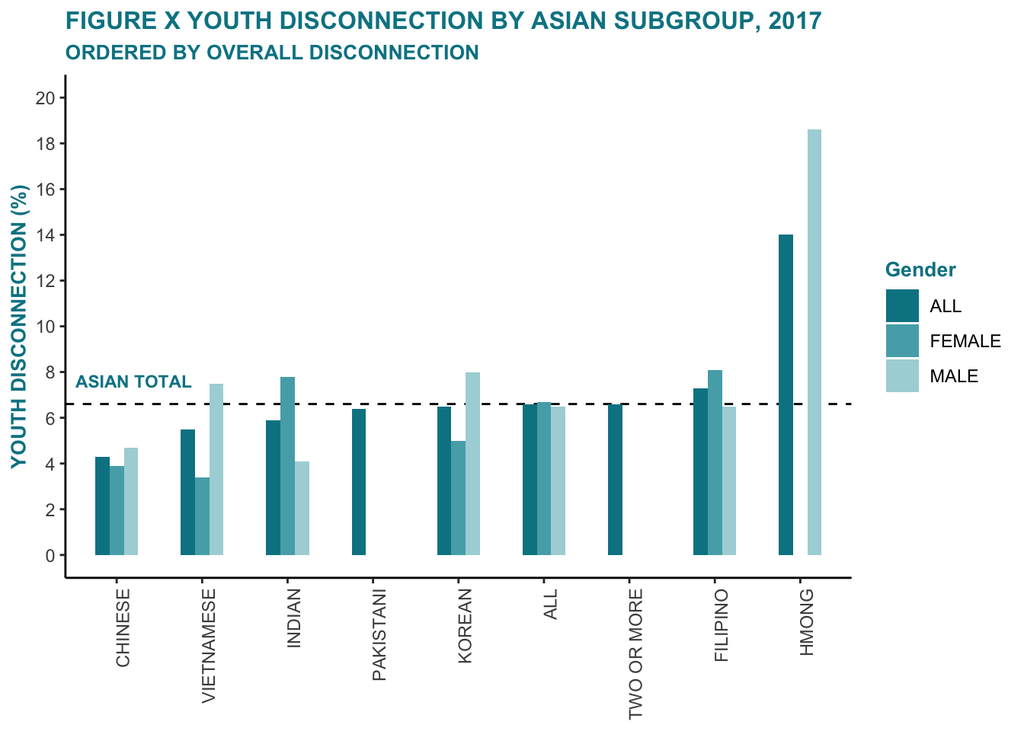

```r
custom_pal <- colorRampPalette(c("white", "#008393"))
gender_n <- 3

asian_total <- df2 %>%
  filter(Year == 2017) %>%
  filter(Gender == "ALL",
         Subgroup == "ALL") %>%
  pull(Rate)

df2 %>%
  filter(Year == 2017) %>%
  complete(Gender, Subgroup) %>%
  group_by(Gender) %>%
  mutate(sub_rank = rank(Rate, ties.method = "min")) %>%
  group_by(Subgroup) %>%
  mutate(rank_all = sub_rank[Gender == "ALL"]) %>%
  ungroup() %>%
  mutate(Subgroup = fct_reorder(Subgroup, rank_all)) %>%
  ggplot(aes(x = Subgroup, y = Rate, fill = Gender)) +
  geom_hline(yintercept = asian_total,
             color = "black",
             linetype = 2) +
  geom_bar(stat = "identity",
           color = "transparent",
           size = 0.5,
           position = "dodge",
           width = 0.5) +
  labs(title = "FIGURE X YOUTH DISCONNECTION BY ASIAN SUBGROUP, 2017",
       subtitle = "ORDERED BY OVERALL DISCONNECTION",
       y = "YOUTH DISCONNECTION (%)",
       fill = "Gender") +
  scale_fill_manual(values = rev(custom_pal(gender_n + 1))) +
  scale_y_continuous(breaks = seq(0,20,2),
                     labels = seq(0,20,2),
                     limits = c(0,20)) +
  theme_classic() +
  theme(title = element_text(size = 10,
                             color = "#008393",
                             face = "bold"),
        axis.title.x = element_blank(),
        axis.text.x = element_text(angle = 90, hjust = 1)) +
  annotate("text", label = 'bold("ASIAN TOTAL")',
           color = "#008393",
           size = 3,
           x = 1.2,
           y = asian_total + 1,
           parse = TRUE)
```

From the above plot, it becomes apparent that the Hmong subgroup produces a small proportion of the total number of asian disconnected youth. The Asian total youth disconnection rate is more alike the youth disconnection rates for all other subgroups than the Hmong youth disconnection rate.

We can confirm this by revisiting the table.

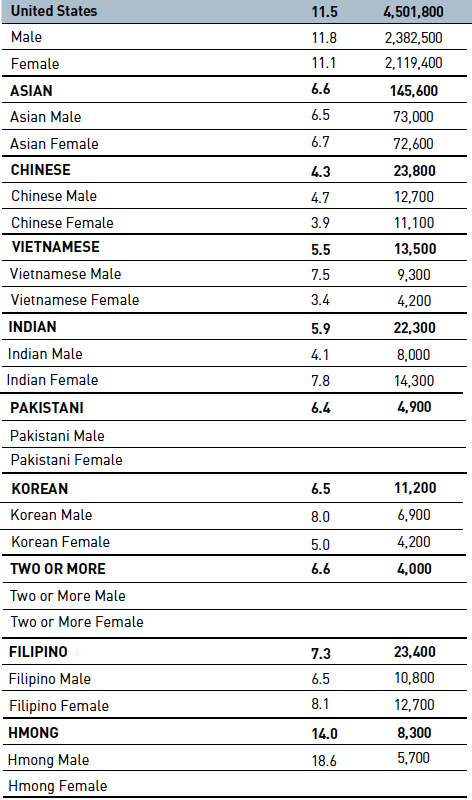

```r
image2
```

The Hmong group represents 6% of all Asian disconnected youth.

This shows the importance of adding small details such as the composite line to plots. It helps provide a simple yet nuanced picture of what is going on.

Lastly, we can add annotations to add provide even more depth to the visualization.

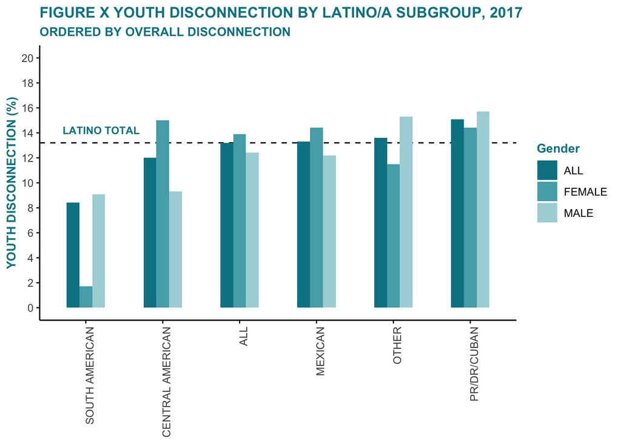

```r
latino_a_total <- df3 %>%
  filter(Year == 2017) %>%
  filter(Gender == "ALL",
         Subgroup == "ALL") %>%
  pull(Rate)

df3 %>%
  filter(Year == 2017) %>%
  complete(Gender, Subgroup) %>%
  group_by(Gender) %>%
  mutate(sub_rank = rank(Rate, ties.method = "min")) %>%
  group_by(Subgroup) %>%
  mutate(rank_all = sub_rank[Gender == "ALL"]) %>%
  ungroup() %>%
  mutate(Subgroup = fct_reorder(Subgroup, rank_all)) %>%
  ggplot(aes(x = Subgroup, y = Rate, fill = Gender)) +
  geom_hline(yintercept = latino_a_total,
             color = "black",
             linetype = 2) +
  geom_bar(stat = "identity",
           color = "transparent",
           size = 0.5,
           position = "dodge",
           width = 0.5) +
  labs(title = "FIGURE X YOUTH DISCONNECTION BY LATINO/A SUBGROUP, 2017",
       subtitle = "ORDERED BY OVERALL DISCONNECTION",
       y = "YOUTH DISCONNECTION (%)",
       fill = "Gender") +
  scale_fill_manual(values = rev(custom_pal(gender_n + 1))) +
  scale_y_continuous(breaks = seq(0,20,2),
                     labels = seq(0,20,2),
                     limits = c(0,20)) +
  theme_classic() +
  theme(title = element_text(size = 10,
                             color = "#008393",
                             face = "bold"),
        axis.title.x = element_blank(),
        axis.text.x = element_text(angle = 90, hjust = 1)) +
  annotate("text", label = 'bold("LATINO TOTAL")',
           color = "#008393",
           size = 3,
           x = 1.2,
           y = latino_a_total + 1,
           parse = TRUE)
```

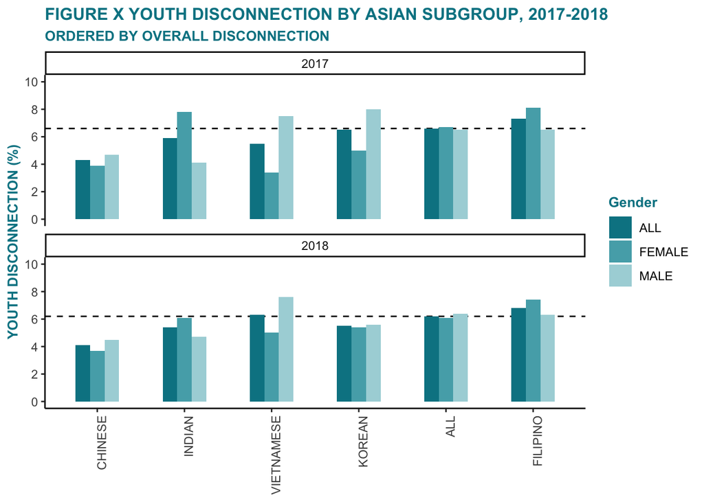

```r
df2 %>%
  complete(Gender, Subgroup, Year) %>%
  group_by(Subgroup) %>%
  mutate(missing = sum(is.na(Rate))) %>%
  filter(missing == 0) %>%
  dplyr::select(-missing) %>%
  ungroup() %>%
  group_by(Gender) %>%
  mutate(sub_rank = rank(Rate, ties.method = "min")) %>%
  group_by(Subgroup, Year) %>%
  mutate(rank_all = sub_rank[Gender == "ALL"]) %>%
  ungroup() %>%
  group_by(Year) %>%
  mutate(threshold = Rate[Gender == "ALL" & Subgroup == "ALL"]) %>%
  ungroup() %>%
  mutate(Subgroup = fct_reorder(Subgroup, rank_all)) %>%
  ggplot(aes(x = Subgroup, y = Rate, fill = Gender)) +
  facet_wrap(Year ~., ncol = 1) +
  geom_hline(aes(yintercept = threshold), linetype = 2) +
  geom_bar(stat = "identity",
           color = "transparent",
           size = 0.5,
           position = "dodge",
           width = 0.5) +
  labs(title = "FIGURE X YOUTH DISCONNECTION BY ASIAN SUBGROUP, 2017-2018",
       subtitle = "ORDERED BY OVERALL DISCONNECTION",
       y = "YOUTH DISCONNECTION (%)",
       fill = "Gender") +
  scale_fill_manual(values = rev(custom_pal(gender_n + 1))) +
  scale_y_continuous(breaks = seq(0,10,2),
                     labels = seq(0,10,2),
                     limits = c(0,10)) +
  theme_classic() +
  theme(title = element_text(size = 10,
                             color = "#008393",
                             face = "bold"),
        axis.title.x = element_blank(),
        axis.text.x = element_text(angle = 90, hjust = 1))
```

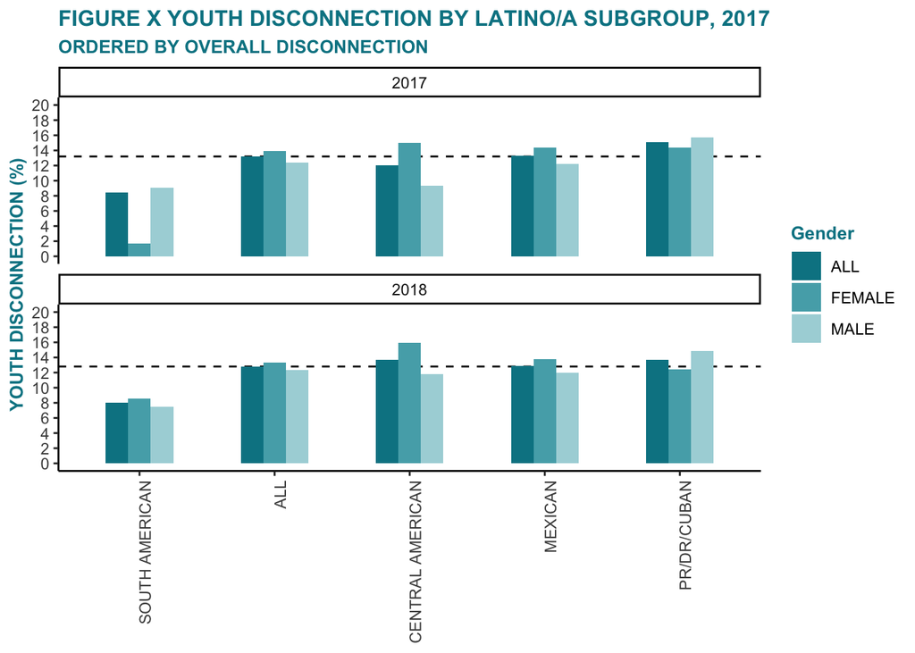

```r
df3 %>%
  complete(Gender, Subgroup, Year) %>%
  group_by(Subgroup) %>%
  mutate(missing = sum(is.na(Rate))) %>%
  filter(missing == 0) %>%
  dplyr::select(-missing) %>%
  ungroup() %>%
  group_by(Gender) %>%
  mutate(sub_rank = rank(Rate, ties.method = "min")) %>%
  group_by(Subgroup, Year) %>%
  mutate(rank_all = sub_rank[Gender == "ALL"]) %>%
  ungroup() %>%
  group_by(Year) %>%
  mutate(threshold = Rate[Gender == "ALL" & Subgroup == "ALL"]) %>%
  ungroup() %>%
  mutate(Subgroup = fct_reorder(Subgroup, rank_all)) %>%
  ggplot(aes(x = Subgroup, y = Rate, fill = Gender)) +
  facet_wrap(Year ~., ncol = 1) +
  geom_hline(aes(yintercept = threshold), linetype = 2) +
  geom_bar(stat = "identity",
           color = "transparent",
           size = 0.5,
           position = "dodge",
           width = 0.5) +
  labs(title = "FIGURE X YOUTH DISCONNECTION BY LATINO/A SUBGROUP, 2017",
       subtitle = "ORDERED BY OVERALL DISCONNECTION",
       y = "YOUTH DISCONNECTION (%)",
       fill = "Gender") +
  scale_fill_manual(values = rev(custom_pal(gender_n + 1))) +
  scale_y_continuous(breaks = seq(0,20,2),
                     labels = seq(0,20,2),
                     limits = c(0,20)) +
  theme_classic() +
  theme(title = element_text(size = 10,
                             color = "#008393",
                             face = "bold"),
        axis.title.x = element_blank(),
        axis.text.x = element_text(angle = 90, hjust = 1))
```

## **Suggested Homework**

1. Find another table in the document. Find differences between groups with the process described above.

## **Helpful Links**

**MICHAEL ONTIVEROS**

*Given the simplicity of this case study, I am assuming that there is a high probability you will be discussing RStudio cheatsheets. I left the link and button below. Feel free to delete as needed.*

**MICHAEL ONTIVEROS**

*This concepts listed here must be revisited.*

Terms and concepts covered:

[Tidyverse](https://www.tidyverse.org/)  
[RStudio cheatsheets](https://rstudio.com/resources/cheatsheets/)  
[Inference](https://www.britannica.com/science/inference-statistics)  
[Regression](https://lindeloev.github.io/tests-as-linear/)  
[Different types of regression](https://www.analyticsvidhya.com/blog/2015/08/comprehensive-guide-regression/)  
[Ordinary least squares method](http://setosa.io/ev/ordinary-least-squares-regression/)  
[Residual](https://www.statisticshowto.datasciencecentral.com/residual/)

Packages used in this case study:

| Package | Use |
| --- | --- |
| [**here**](https://github.com/jennybc/here_here) | to easily load and save data |
| [**tidyverse**](https://readr.tidyverse.org/) | for data science operations |
| [**pdftools**](https://readr.tidyverse.org/) | to manage PDF documents |
| [**magick**](https://cran.r-project.org/web/packages/magick/vignettes/intro.html#Kernel_convolution) | for image processing |